# Week 4 Assignment: Markov Chain Monte Carlo

Joshua Goldberg

October, 22 2018

Explore bivariate normal distribution density using MCMC.

# 1 Bivariate normal distribution

Set parameters of bivariate normal distribution $<\mu_1,\mu_2,\sigma_1,\sigma_2,\rho>$

```r
myDenParams <- c(1, 1, 5, 5, .8)
```

Create a function `den <- function(argmts, params)`, where argmts is vector $<x_1,x_2>$ and params is vector of distribution parameters $<\mu_1,\mu_2,\sigma_1,\sigma_2,\rho>$ implementing formula for bivariate normal distribution density
$$f(x_1,x_2)=\frac{1}{2\pi\sigma_1\sigma_2\sqrt{1-\rho^2}}e^\frac{-z}{2(1-\rho^2)}$$
, where
$$z=\frac{(x_1−\mu_1)^2}{\sigma^2_1}−\frac{2\rho(x_1−\mu_1)(x_2−\mu_2)}{\sigma_1\sigma_2}+\frac{(x_2−\mu_2)^2}{\sigma^2_2}$$

```r
calc_z <- function(x, mu1, mu2, sigma1, sigma2, rho) {
  x1 <- x[1]
  x2 <- x[2]
  ((x1 - mu1)^2 / sigma1^2) - ((2 * rho * (x1 - mu1) * (x2 - mu2)) / (sigma1 * sigma2)) + ((x2 - mu2)^2 / (sigma2^2))
}

den <- function(argmts, params, sigProp) {
  x1 <- argmts[1]
  x2 <- argmts[2]
  mu1 <- params[1]
  mu2 <- params[2]
  sigma1 <- params[3]
  sigma2 <- params[4]
  rho <- params[5]
  (1 / (2 * pi * sigma1 * sigma2 * sqrt(1 - rho^2))) * exp(1)^((-calc_z(c(x1, x2), mu1, mu2, sigma1, sigma2, rho)) / (2 * (1 - rho^2)))
}

den(c(1, 1), myDenParams)
```

```
## [1] 0.01061033
```

# 2 Metropolis rule

Create a function `oneStep <- function(denFun, initSt, denParams, sigProp)`, where:

- `denFun` is name of the function for exploration. In this case it is `den`
- `initSt` is initial vector of arguments $<x1,x2>$
- `denParams` is vector of parameters of bivariate normal distribution
- `sigProp` is standard deviation of the distribution generating proposals: Gaussian with zero mean and standard deviation `sigProp`

Function returns vector of 3 elements: generated proposal $<x1,x2>$ and acceptance indicator which equals 1 if proposal is accepted and 0 if it is rejected.

```r
oneStep <- function(denFun, initSt, denParams, sigProp) {
  new_proposal <- initSt + rnorm(2, mean = 0, sd = sigProp)
  initSt_probs <- denFun(initSt, denParams)
  new_proposal_probs <- denFun(new_proposal, denParams)

  if (new_proposal_probs > initSt_probs) {
    accept <- 1
  } else {
    p <- new_proposal_probs / initSt_probs
    accept <- sample(c(0, 1), 1, prob = c(1 - p, p))
  }

  data.frame(x1 = new_proposal[1], x2 = new_proposal[2], accept)
}
```

# 3 Run MCMC

Use function `oneStep()` to repeat 10000 iterations of MCMC. Collect accepted proposals in a matrix trajectory containing one column for $x_1$ and another column for $x_2$. Collect rejected proposals in matrix rejections. Select some initial point.

```r
init <- c(10, -10)
```

Plot MCMC trajectory and rejected proposals.

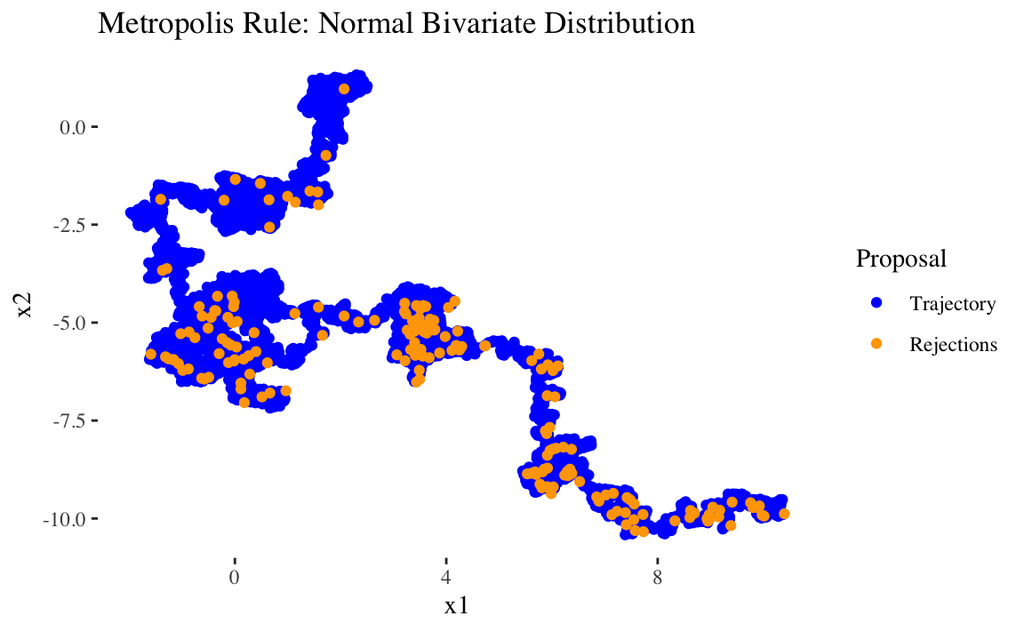

```r
run_mcmc <- function(iterations, init, sigProp) {
  result <-
    data.frame(
      x1 = vector("numeric", iterations),
      x2 = vector("numeric", iterations),
      accept = vector("numeric", iterations)
    )

  for (i in 1:iterations) {
    result[i, ] <- oneStep(den, init, myDenParams, sigProp)
    init <- switch(result$accept[[i]] + 1,
                   init,
                   c(result$x1[[i]], result$x2[[i]]))
  }

  result
}

set.seed(1)
result <- run_mcmc(10000, c(10, -10), .05)

result_plot <- result %>%
  mutate(accept = factor(accept, levels = c(0, 1), labels = c("Rejections", "Trajectory")))

result_plot %>%
  arrange(desc(accept)) %>%
  ggplot(aes(x1, x2, color = accept)) +
  geom_point() +
  scale_color_manual(name = "Proposal", values = c("orange", "blue"), guide = guide_legend(reverse = TRUE)) +
  labs(title = "Metropolis Rule: Normal Bivariate Distribution")
```

## Run MCMC from Different Initial Starts

Make sure both trajectories converge to the same area of exploration.

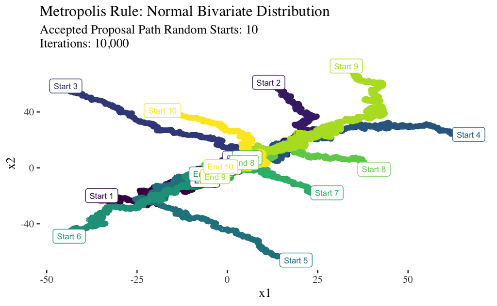

```r
# How many runs?
runs <- 1:10
iteration <- 10000
set.seed(1)
init <- rerun(length(runs), sample(-75:75, 2))
sd <- .179982

plan(multiprocess)
multi_result <- furrr::future_pmap(
  list(
    iterations = rep(iteration, each = length(runs)),
    init = init,
    sigProp = rep(sd, each = length(runs)),
    runs = runs
  ),
  function(iterations, init, sigProp, runs) {
    run_mcmc(iterations, init, sigProp) %>%
      mutate(run = runs)
  })

plot_all_data <- map(multi_result, ~ mutate(
  .x,
  accept = factor(
    accept,
    levels = c(0, 1),
    labels = c("Rejections", "Trajectory")
  )
)) %>%
  bind_rows() %>%
  filter(accept == "Trajectory") %>%
  mutate(run = factor(run))

start <- plot_all_data %>% split(.$run) %>% map( ~ head(.x, 1)) %>% bind_rows()
end <- plot_all_data %>% split(.$run) %>% map( ~ tail(.x, 1)) %>% bind_rows()

plot_all_data %>%
  ggplot(aes(x1, x2, color = run)) +
  geom_point(shape = 1) +
  geom_label(data = start, aes(x1, x2, label = glue::glue("Start {run}")), size = 2.5) +
  geom_label(data = end, aes(x1, x2, label = glue::glue("End {run}")), size = 2.5) +
  scale_color_viridis_d(guide = FALSE) +
  labs(title = "Metropolis Rule: Normal Bivariate Distribution",
       subtitle = glue::glue("Accepted Proposal Path Random Starts: {length(runs)}
                             Iterations: {scales::comma(iteration)}"))
```

## Try Different `sigProp` Values

```r
multi_start <- function(runs, iteration, seed, sd) {
  set.seed(seed)
  init <- rerun(length(runs), sample(-75:75, 2))

  plan(multiprocess)
  multi_result <- furrr::future_pmap(
    list(
      iterations = rep(iteration, each = length(runs)),
      init = init,
      sigProp = rep(sd, each = length(runs)),
      runs = runs
    ),
    function(iterations, init, sigProp, runs) {
      run_mcmc(iterations, init, sigProp) %>%
        mutate(run = runs)
    })

  plot_all_data <- map(multi_result, ~ mutate(
    .x,
    accept = factor(
      accept,
      levels = c(0, 1),
      labels = c("Rejections", "Trajectory")
    )
  )) %>%
    bind_rows() %>%
    filter(accept == "Trajectory") %>%
    mutate(run = factor(run))

  start <- plot_all_data %>% split(.$run) %>% map( ~ head(.x, 1)) %>% bind_rows()
  end <- plot_all_data %>% split(.$run) %>% map( ~ tail(.x, 1)) %>% bind_rows()
  list(plot_data = plot_all_data, start = start, end = end, sd = sd)
}

metropolis_grid <- function(param, runs, columns, iterations = NULL, sd_test = FALSE, default_sd = NULL, seed = NULL) {
  if (!sd_test & is.null(default_sd)) {
    stop("default_sd is NULL. Specification required for sd_test")
  }

  sd <- default_sd

  if (sd_test) {
    subtitles <- glue::glue("Standard deviation: {param}")
    main_subtitle <- glue::glue("Iterations: {scales::comma(iterations)}")
  } else {
    subtitles <- glue::glue("Iterations: {scales::comma(param)}")
    main_subtitle <- glue::glue("Standard deviation: {sd}")
  }

  plan(multiprocess)
  if (sd_test) {
    results <-
      furrr::future_map(param, ~ multi_start(
                          runs,
                          iteration = iterations,
                          seed = seed,
                          sd = .x
                        ))
  } else {
    results <-
      furrr::future_map(param, ~ multi_start(
                          runs,
                          iteration = .x,
                          seed = seed,
                          sd = sd
                        ))
  }
  plots <- furrr::future_map2(results, subtitles, function(data, subtitles) {
    data$plot_data %>%
      ggplot(aes(x1, x2, color = run)) +
      geom_point(shape = 1) +
      geom_label(data = data$start, aes(x1, x2, label = glue::glue("Start {run}")), size = 2.5) +
      geom_label(data = data$end, aes(x1, x2, label = glue::glue("End {run}")), size = 2.5) +
      scale_color_viridis_d(guide = FALSE) +
      labs(title = NULL,
         subtitle = subtitles,
         x = NULL,
         y = NULL)
    }
  )

  title_grob <- grid::textGrob(
    label = glue::glue('Metropolis Rule: Normal Bivariate Distribution
    Accepted Proposal Path Random Starts: {length(runs)}
    {main_subtitle}'),
    x = unit(.5, "lines"),
    y = unit(0, "lines"),
    hjust = 0,
    vjust = 0,
    gp = grid::gpar(fontface = "bold"))

  grid_args <- c(plots, list(ncol = columns,
                             top = title_grob,
                             bottom = grid::textGrob("x1"),
                             left = grid::textGrob("x2", rot = 90, vjust = 1)))
  invoke(gridExtra::grid.arrange, grid_args)
}
```

## Random Start Convergence

There are two noticeable factors that influence the agreement among random starts: `sigProp` and `iterations`. Both have a positive relationship with random start convergence. Here we explore the relationship between `sigProp` and random start convergence:

```r
metropolis_grid(
  param = seq(.025, .4, .075),
  runs = 1:3,
  iterations = 10000,
  sd_test = TRUE,
  columns = 3,
  seed = 1
)
```

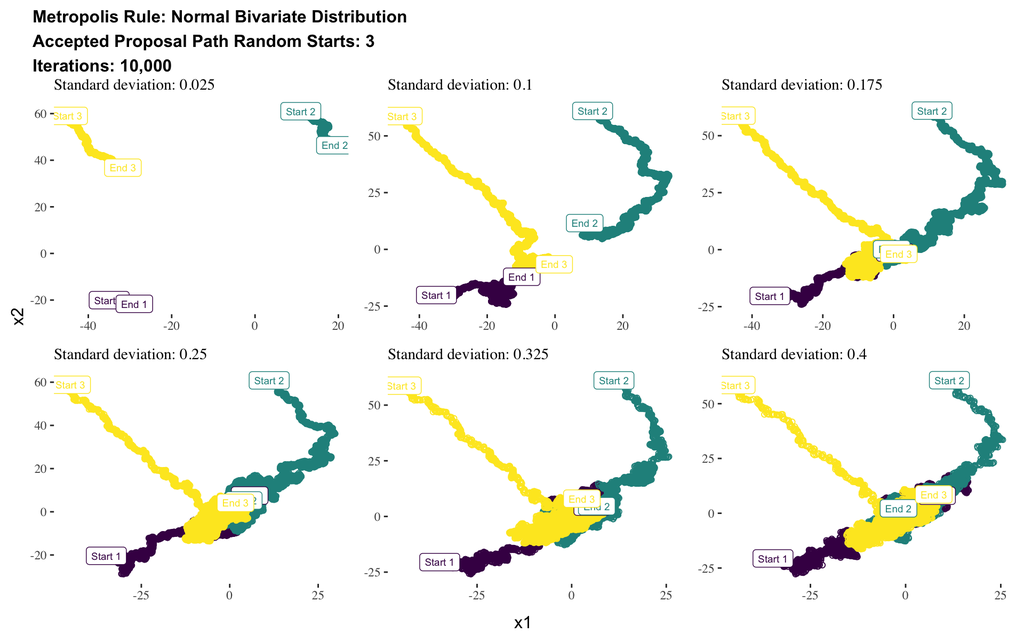

```r
metropolis_grid(
  param = seq(0.475, .8, .055),
  runs = 1:3,
  iteration = 10000,
  sd_test = TRUE,
  columns = 3,
  seed = 1
)
```

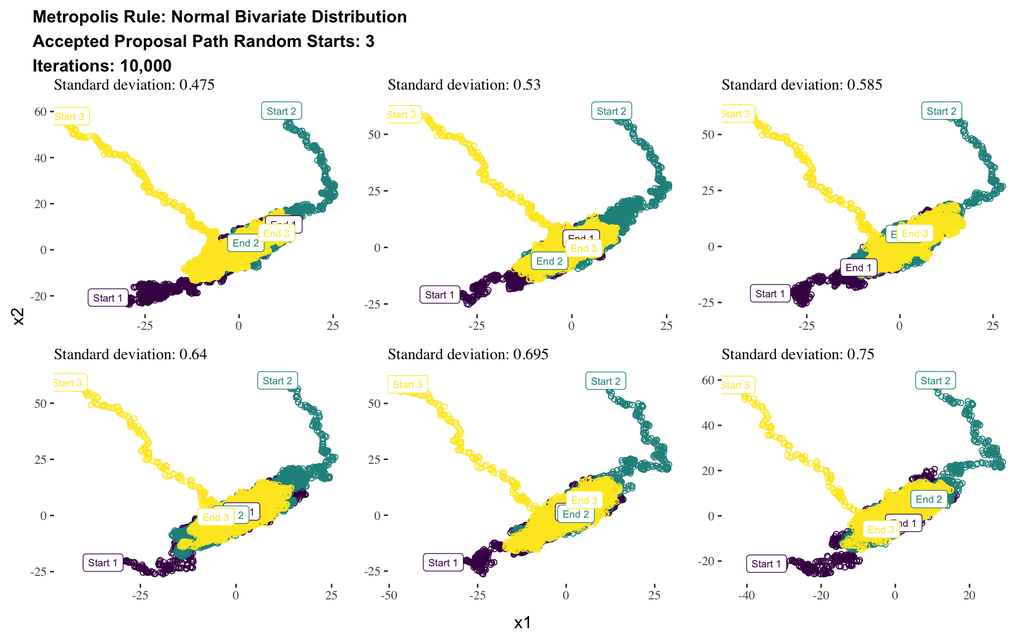

And `iterations`:

```r
metropolis_grid(
  param = seq(1000, 50000, 9000),
  default_sd = .05,
  runs = 1:3,
  columns = 3,
  seed = 1
)
```

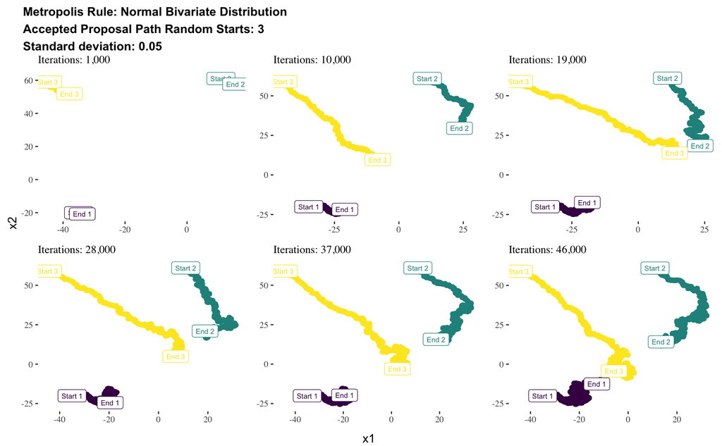

```r
metropolis_grid(
  param = seq(54000, 100000, 9000),
  default_sd = .05,
  runs = 1:3,
  columns = 3,
  seed = 1
)
```

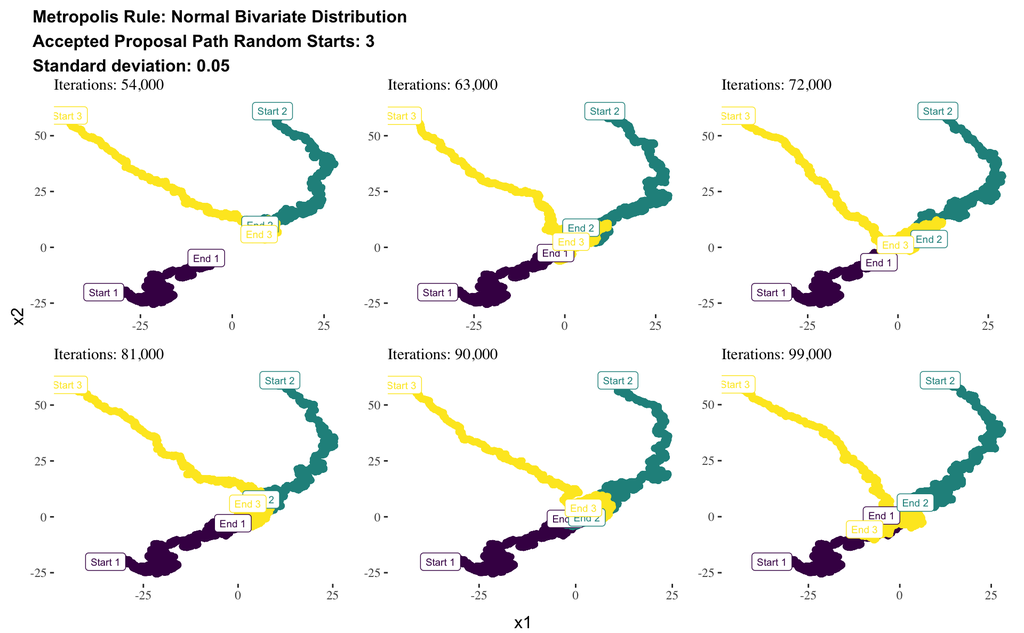